# Part I - (Ford GoBike System Data)

### What are the top 10 Start stations with user traffic?

```python
stations = df_cleaned.start_station_id.value_counts().reset_index()
stations = stations.rename(columns = {'index': 'start_station_id','start_station_id':'count' }).head(10)
df_stations = stations.merge(df_cleaned, on = 'start_station_id', how = 'left')
lab = df_stations.groupby('start_station_id')['start_station_name'].value_counts().reset_index(level = 0)
labels = lab.index
```

[figure not shown]

```python
plt.figure(figsize = (15,5))
color = sb.color_palette()[0]
freq = df_stations['start_station_id'].value_counts()
order = freq.index
g = sb.barplot( data = df_stations, x= 'count', y = 'start_station_id', color = color)
g.set_yticklabels(labels)
plot_names('Fig 9: Top 10 Start stations with Traffic','Total No of Rides','Station Address')
```

> This would be a good metric in selecting stations to place ads

### What are the top 10 End stations with user traffic?

```python
end_stations = df_cleaned.end_station_id.value_counts().reset_index()
end_stations = end_stations.rename(columns = {'index': 'end_station_id','end_station_id':'count' }).head(10)
df_end_stations = end_stations.merge(df_cleaned, on = 'end_station_id', how = 'left')
end_lab = df_end_stations.groupby('end_station_id')['end_station_name'].value_counts().reset_index(level = 0)
end_labels = end_lab.index
```

[figure not shown]

```python
plt.figure(figsize = (15,5))
color = sb.color_palette()[2]
end_freq = df_end_stations['end_station_id'].value_counts()
end_order = end_freq.index

g = sb.barplot( data = df_end_stations, y= 'end_station_id', x = 'count', color = color, order = end_order)
g.set_yticklabels(end_labels)
plot_names('Fig 10: Top 10 End stations with user Traffic','Total No of Rides','Station Address')
```

> This would be a good metric in selecting stations to place ads

### Talk about some of the relationships you observed in this part of the investigation. How did the feature(s) of interest vary with other features in the dataset?

> There are significantly more Categorical Variables than Numerical variables in this dataset. The following were observed based on the visualisations above
> 1. There are significantly more male than any other gender type in the data set
> 2. There are significantly more Subscribers than regular customers in the data set
> 3. Men tend to use less time per trip on average compared to women and others

### Did you observe any interesting relationships between the other features (not the main feature(s) of interest)?

> There is no significant relationship between the age of the riders and the duration of the trip

## Multivariate Exploration

> In this section, we shall create plots of three or more variables to investigate the data even further.

### How are the user types distributed across member gender?

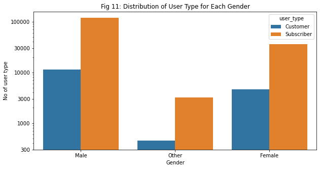

```python
fig, ax = plt.subplots(figsize=(10, 5))
g = sb.countplot(data = df_cleaned, x ='member_gender', hue = 'user_type', ax=ax )
ticks = [300, 1000, 3000, 10000, 30000,100000]
labels = ['{}'.format(v) for v in ticks]
g.set_yscale('log')
g.set_yticks(ticks)
g.set_yticklabels(labels)
plot_names('Fig 11: Distribution of User Type for Each Gender','Gender','No of user type')
```

> The Chart above shows the distribution of user type for each Gender.

> The chart shows that there are more subscibers than customers for each gender type

> Males have more subscribers and customers given that there are more males than any other gender type in this dataset as illustrated in Fig 2 above

### How does the Gender affect the bike share for all trip?

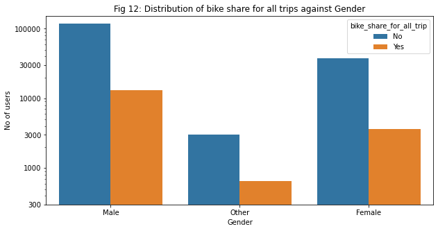

```python
fig, ax = plt.subplots(figsize=(10, 5))
g = sb.countplot(data = df_cleaned, x ='member_gender', hue = 'bike_share_for_all_trip' )
ticks = [300, 1000, 3000, 10000, 30000,100000]
labels = ['{}'.format(v) for v in ticks]
g.set_yscale('log')
g.set_yticks(ticks)
g.set_yticklabels(labels)
plot_names('Fig 12: Distribution of bike share for all trips against Gender','Gender','No of users')
```

> The chart above illustrates the distribution of bike sharing for all trips against Gender

> The chart above shows a similar trend across all gender types. People generally prefer not to share bikes for all trips.

### How does bike sharing for all trips affect the duration of the trip.?

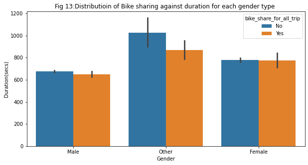

```python
fig, ax = plt.subplots(figsize=(10, 5))
g = sb.barplot(data = df_cleaned, x = 'member_gender', y = 'duration_sec', hue = 'bike_share_for_all_trip')
plot_names('Fig 13:Distributioin of Bike sharing against duration for each gender type ','Gender','Duration(secs)')
```

> The chart abov shows the average duration for each gender type and how the duration is affected by bike sharing for all trips

> Interestingly, the chart above suggests that the average duration per trip across all genders is lower with bike sharing.

### What are the Top 10 start stations and what is the gender distribution in these stations?

```python
stations = df_cleaned.start_station_id.value_counts().reset_index()
stations = stations.rename(columns = {'index': 'start_station_id','start_station_id':'count' }).head(10)
df_stations = stations.merge(df_cleaned, on = 'start_station_id', how = 'left')
lab = df_stations.groupby('start_station_id')['start_station_name'].value_counts().reset_index(level = 0)
labels = lab.index
```

[figure not shown]

```python
plt.figure(figsize = (10,5))
color = sb.color_palette()[2]
ticks = [50, 100, 500 , 1000, 1500]
xylabels = ['{}'.format(v) for v in ticks]
g = sb.countplot( data = df_stations, y= 'start_station_id', hue = 'member_gender', color =color)
g.set_yticklabels(labels)
g.set_xscale('log')
g.set_xticks(ticks)
g.set_xticklabels(xylabels)
plot_names('Fig 14: Top 10 start stations with Gender','Total No of Rides','Station Address')
```

> The chart above shows the top 10 start stations distributed by gender.

> It can be seen that Males generally seem to be the highest contributors to traffic across all stations

### What are the Top 10 End stations and what is the gender distribution in these stations?

```python
end_stations = df_cleaned.end_station_id.value_counts().reset_index()
end_stations = end_stations.rename(columns = {'index': 'end_station_id','end_station_id':'count' }).head(10)
df_end_stations = end_stations.merge(df_cleaned, on = 'end_station_id', how = 'left')
end_lab = df_end_stations.groupby('end_station_id')['end_station_name'].value_counts().reset_index(level = 0)
end_labels = end_lab.index
```

[figure not shown]

```python
plt.figure(figsize = (10,5))
color = sb.color_palette()[0]
ticks = [50, 100, 500 , 1000, 1500]
xylabels = ['{}'.format(v) for v in ticks]
g = sb.countplot( data = df_end_stations, y= 'end_station_id', hue = 'member_gender', color = color)
g.set_yticklabels(labels)
g.set_xscale('log')
g.set_xticks(ticks)
g.set_xticklabels(xylabels)
plot_names('Fig 15: Top 10 End stations with Gender','Total No of Rides','Station Address')
```

> The chart above shows the top 10 end stations distributed by gender.

> It can be seen that Males generally seem to be the highest contributors to traffic across all stations

### Talk about some of the relationships you observed in this part of the investigation. Were there features that strengthened each other in terms of looking at your feature(s) of interest?

> The following were observed on the visualisations above:
> 1. There are generally more subscribers than regular customers across all gender types, however, Males have more subscribers and customers given that there are more males than any other gender type in this dataset as illustrated in Fig 2 above.
> 2. People generally prefer not to share bikes for all trips.
> 3. Males generally seem to be the highest contributors to station traffic relative to other gender types

### Were there any interesting or surprising interactions between features?

> NO